# Predicting Earnings from Census Data

# Introduction

The United States government periodically collects demographic information by conducting a census.

In this problem, we are going to use census information about an individual to predict how much a person earns – in particular, whether the person earns more than $50,000 per year. This data comes from the [UCI Machine Learning Repository](http://archive.ics.uci.edu/ml/datasets/Adult).

The file census.csv contains 1994 census data for 31,978 individuals in the United States.

The dataset includes the following 13 variables:

**age** : the age of the individual in years  
**workclass** : the classification of the individual’s working status (does the person work for the federal government, work for the local government, work without pay, and so on)  
**education** : the level of education of the individual (e.g., 5th-6th grade, high school graduate, PhD, so on)  
**maritalstatus** : the marital status of the individual  
**occupation** : the type of work the individual does (e.g., administrative/clerical work, farming/fishing, sales and so on)  
**relationship** : relationship of individual to his/her household  
**race** : the individual’s race  
**sex** : the individual’s sex  
**capitalgain** : the capital gains of the individual in 1994 (from selling an asset such as a stock or bond for more than the original purchase price)  
**capitalloss** : the capital losses of the individual in 1994 (from selling an asset such as a stock or bond for less than the original purchase price)  
**hoursperweek** : the number of hours the individual works per week  
**nativecountry** : the native country of the individual  
**over50k** : whether or not the individual earned more than $50,000 in 1994

# Exercices

## **1. A Logistic Regression Model**

#### Problem 1.1

Let’s begin by building a logistic regression model to predict whether an individual’s earnings are above $50,000 (the variable “over50k”) using all of the other variables as independent variables. First, read the dataset census.csv into R.

Then, split the data randomly into a training set and a testing set, **setting the seed to 2000** before creating the split. Split the data so that the **training set contains 60%** of the observations, while the testing set contains 40% of the observations.

Next, build a logistic regression model to predict **the dependent variable “over50k”**, using all of the other variables in the dataset as independent variables. Use the training set to build the model.

**Which variables are significant, or have factors that are significant?** (Use 0.1 as your significance threshold, so variables with a period or dot in the stars column should be counted too. You might see a warning message here - you can ignore it and proceed. This message is a warning that we might be overfitting our model to the training set.)  
Select all that apply.

```
## 'data.frame':    31978 obs. of  13 variables:
##  $ age          : int  39 50 38 53 28 37 49 52 31 42 ...
##  $ workclass    : Factor w/ 9 levels " ?"," Federal-gov",..: 8 7 5 5 5 5 5 7 5 5 ...
##  $ education    : Factor w/ 16 levels " 10th"," 11th",..: 10 10 12 2 10 13 7 12 13 10 ...
##  $ maritalstatus: Factor w/ 7 levels " Divorced"," Married-AF-spouse",..: 5 3 1 3 3 3 4 3 5 3 ...
##  $ occupation   : Factor w/ 15 levels " ?"," Adm-clerical",..: 2 5 7 7 11 5 9 5 11 5 ...
##  $ relationship : Factor w/ 6 levels " Husband"," Not-in-family",..: 2 1 2 1 6 6 2 1 2 1 ...
##  $ race         : Factor w/ 5 levels " Amer-Indian-Eskimo",..: 5 5 5 3 3 5 3 5 5 5 ...
##  $ sex          : Factor w/ 2 levels " Female"," Male": 2 2 2 2 1 1 1 2 1 2 ...
##  $ capitalgain  : int  2174 0 0 0 0 0 0 0 14084 5178 ...
##  $ capitalloss  : int  0 0 0 0 0 0 0 0 0 0 ...
##  $ hoursperweek : int  40 13 40 40 40 40 16 45 50 40 ...
##  $ nativecountry: Factor w/ 41 levels " Cambodia"," Canada",..: 39 39 39 39 5 39 23 39 39 39 ...
##  $ over50k      : Factor w/ 2 levels " <=50K"," >50K": 1 1 1 1 1 1 1 2 2 2 ...
```

```
##
## Call:
## glm(formula = over50k ~ ., family = binomial, data = train)
##
## Deviance Residuals:
##     Min       1Q   Median       3Q      Max
## -5.1065  -0.5037  -0.1804  -0.0008   3.3383
##
## Coefficients: (1 not defined because of singularities)
##                                            Estimate Std. Error z value
## (Intercept)                              -8.658e+00  1.379e+00  -6.279
## age                                       2.548e-02  2.139e-03  11.916
## workclass Federal-gov                     1.105e+00  2.014e-01   5.489
## workclass Local-gov                       3.675e-01  1.821e-01   2.018
## workclass Never-worked                   -1.283e+01  8.453e+02  -0.015
## workclass Private                         6.012e-01  1.626e-01   3.698
## workclass Self-emp-inc                    7.575e-01  1.950e-01   3.884
## workclass Self-emp-not-inc                1.855e-01  1.774e-01   1.046
## workclass State-gov                       4.012e-01  1.961e-01   2.046
## workclass Without-pay                    -1.395e+01  6.597e+02  -0.021
## education 11th                            2.225e-01  2.867e-01   0.776
## education 12th                            6.380e-01  3.597e-01   1.774
## education 1st-4th                        -7.075e-01  7.760e-01  -0.912
## education 5th-6th                        -3.170e-01  4.880e-01  -0.650
## education 7th-8th                        -3.498e-01  3.126e-01  -1.119
## education 9th                            -1.258e-01  3.539e-01  -0.355
## education Assoc-acdm                      1.602e+00  2.427e-01   6.601
## education Assoc-voc                       1.541e+00  2.368e-01   6.506
## education Bachelors                       2.177e+00  2.218e-01   9.817
## education Doctorate                       2.761e+00  2.893e-01   9.544
## education HS-grad                         1.006e+00  2.169e-01   4.638
## education Masters                         2.421e+00  2.353e-01  10.289
## education Preschool                      -2.237e+01  6.864e+02  -0.033
## education Prof-school                     2.938e+00  2.753e-01  10.672
## education Some-college                    1.365e+00  2.195e-01   6.219
## maritalstatus Married-AF-spouse           2.540e+00  7.145e-01   3.555
## maritalstatus Married-civ-spouse          2.458e+00  3.573e-01   6.880
## maritalstatus Married-spouse-absent      -9.486e-02  3.204e-01  -0.296
## maritalstatus Never-married              -4.515e-01  1.139e-01  -3.962
## maritalstatus Separated                   3.609e-02  1.984e-01   0.182
```

[output cut: 162 more lines]

```
## nativecountry Thailand                   0.329678
## nativecountry Trinadad&Tobago            0.434105
## nativecountry United-States              0.946020
## nativecountry Vietnam                    0.507799
## nativecountry Yugoslavia                 0.394874
## ---
## Signif. codes:  0 '***' 0.001 '**' 0.01 '*' 0.05 '.' 0.1 ' ' 1
##
## (Dispersion parameter for binomial family taken to be 1)
##
##     Null deviance: 21175  on 19186  degrees of freedom
## Residual deviance: 12104  on 19090  degrees of freedom
## AIC: 12298
##
## Number of Fisher Scoring iterations: 15
```

**Answer** :

1. **age**
2. **workclass**
3. **education**
4. **maritalstatus**
5. **occupation**
6. **relationship**
7. race
8. **sex**
9. **capitalgain**
10. **capitalloss**
11. **hoursperweek**
12. nativecountry

#### Problem 1.2

**What is the accuracy of the model on the testing set? Use a threshold of 0.5.**

$$Accuracy = \frac{TruePositive+TrueNegative}{Ntotal}$$

(You might see a warning message when you make predictions on the test set - you can safely ignore it.)

```
##
##          FALSE TRUE
##    <=50K  9051  662
##    >50K   1190 1888
```

```
## [1] 0.8552107
```

**Answer** : 0.8552107

If we divide the sum of the main diagonal by the sum of all of the entries in the matrix, we obtain the accuracy:  
(9051+1888)/(9051+662+1190+1888) = 0.8552107

#### Problem 1.3

**What is the baseline accuracy for the testing set?**

$$baseline method = \frac{TN+FalsePositive}{Ntotal}$$

```
##
##          FALSE TRUE
##    <=50K  9051  662
##    >50K   1190 1888
```

```
## [1] 0.7593621
```

**Answer** : 0.7593621

The baseline accuracy is:  
9713/(9713+3078) = 0.7593621.

#### Problem 1.4

**What is the area-under-the-curve (AUC) for this model on the test set?**

```
## [1] 0.9061598
```

**Answer** : 0.9061598

## **2. A CART Model**

#### Problem 2.1

We have just seen how the logistic regression model for this data achieves a high accuracy. Moreover, the significances of the variables give us a way to gauge which variables are relevant for this prediction task. However, it is not immediately clear which variables are more important than the others, especially due to the large number of factor variables in this problem.

Let us now build a classification tree to predict “over50k”. Use the training set to build the model, and all of the other variables as independent variables. Use the default parameters, so don’t set a value for minbucket or cp. Remember to specify method=“class” as an argument to rpart, since this is a classification problem. After you are done building the model, plot the resulting tree.

**How many splits does the tree have in total?**

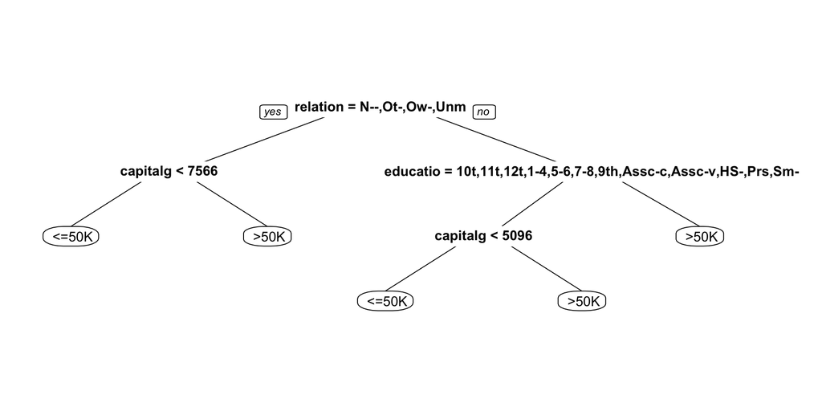

**Answer** : 4

There are four splits in total.

#### Problem 2.2

**Which variable does the tree split on at the first level (the very first split of the tree)?**

**Answer** :

1. age
2. workclass
3. education
4. maritalstatus
5. occupation
6. **relationship**
7. race
8. sex
9. capitalgain
10. capitalloss
11. hoursperweek
12. nativecountry

**Explanation** :  
Plot the tree and examine the first split:

The first split uses the variable relationship.

#### Problem 2.3

**Which variables does the tree split on at the second level (immediately after the first split of the tree)?**  
Select all that apply.

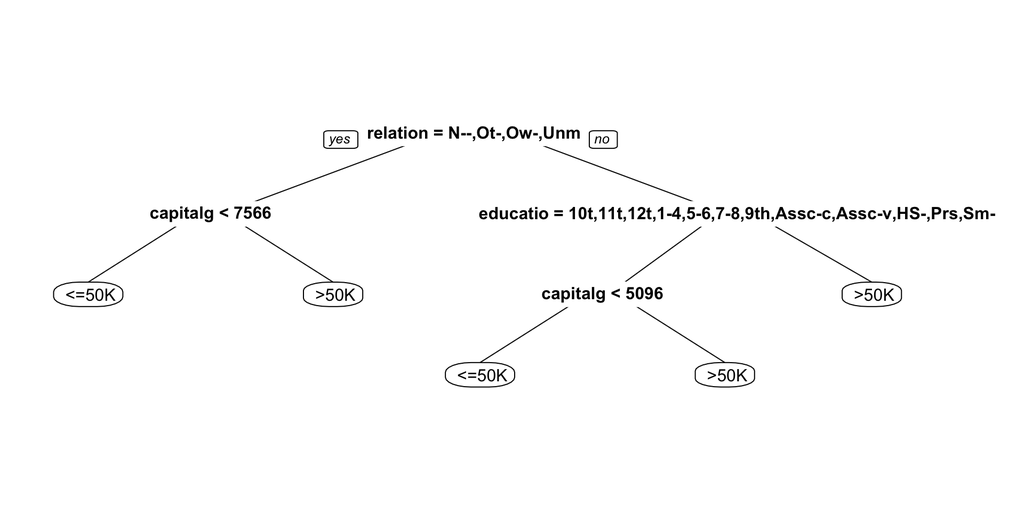

**Answer** :

1. age
2. workclass
3. **education**
4. maritalstatus
5. occupation
6. relationship
7. race
8. sex
9. **capitalgain**
10. capitalloss
11. hoursperweek
12. nativecountry

**Explanation** :  
Plot the tree and examine the second splits:

The second splits are on capitalgains and education.

#### Problem 2.4

**What is the accuracy of the model on the testing set?**  
Use a threshold of 0.5. (You can either add the argument type=“class”, or generate probabilities and use a threshold of 0.5 like in logistic regression.)

$$Accuracy = \frac{TruePositive+TrueNegative}{Ntotal}$$

```
##         censusCART.pred
##           <=50K  >50K
##    <=50K   9243   470
##    >50K    1482  1596
```

```
## [1] 0.8473927
```

**Answer** : 0.8473927

This highlights a very regular phenomenon when comparing CART and logistic regression. CART often performs a little worse than logistic regression in out-of-sample accuracy. However, as is the case here, the CART model is often much simpler to describe and understand.

To compute the accuracy, sum the diagonal entries and divide by the sum of all of the terms:  
(9243+1596)/(9243+470+1482+1596) = 0.8473927

#### Problem 2.5

Let us now consider the ROC curve and AUC for the CART model on the test set. You will need to get predicted probabilities for the observations in the test set to build the ROC curve and compute the AUC. Remember that you can do this by removing the type=“class” argument when making predictions, and taking the second column of the resulting object.

Plot the ROC curve for the CART model you have estimated. Observe that compared to the logistic regression ROC curve, the CART ROC curve is less smooth than the logistic regression ROC curve.  
**Which of the following explanations for this behavior is most correct?**  
(HINT: Think about what the ROC curve is plotting and what changing the threshold does.)

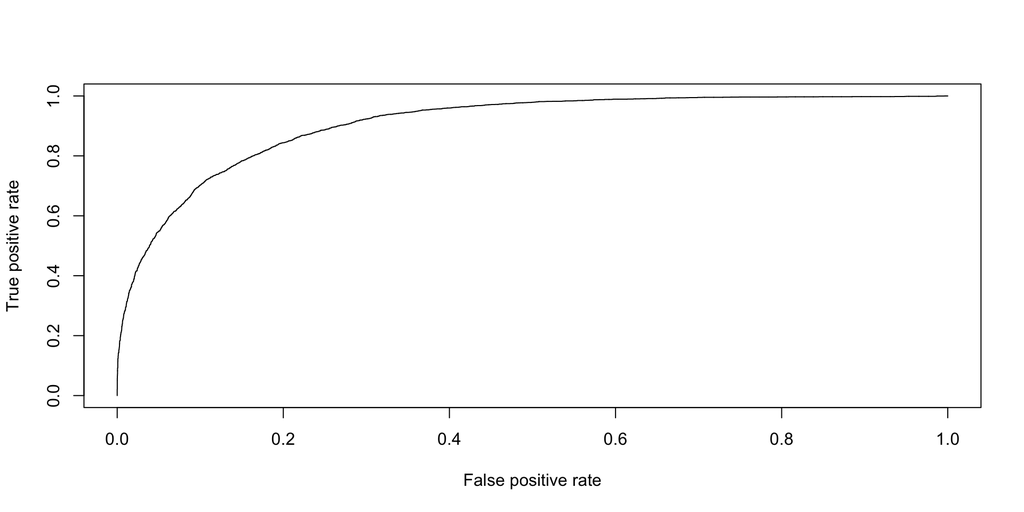

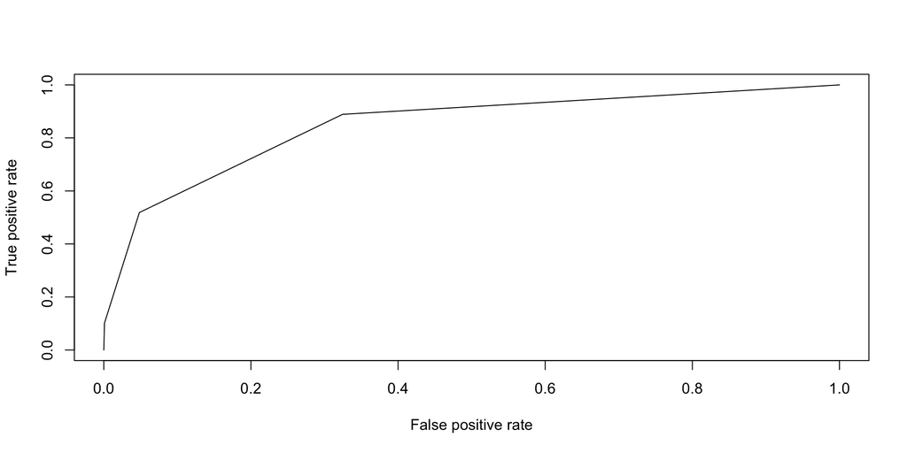

```
## [1] 0.8470256
```

**Answer** :

1. The number of variables that the logistic regression model is based on is larger than the number of variables used by the CART model, so the ROC curve for the logistic regression model will be smoother.
2. CART models require a higher number of observations in the testing set to produce a smoother/more continuous ROC curve; there is simply not enough data.
3. **The probabilities from the CART model take only a handful of values (five, one for each end bucket/leaf of the tree); the changes in the ROC curve correspond to setting the threshold to one of those values.**
4. The CART model uses fewer continuous variables than the logistic regression model (capitalgain for CART versus age, capitalgain, capitallosses, hoursperweek), which is why the CART ROC curve is less smooth than the logistic regression one.

**Explanation** :  
Choice 1 is on the right track, but is incorrect, because the number of variables that you use in a model does not determine how the ROC curve looks. In particular, try fitting logistic regression with hourperweek as the only variable; you will see that the ROC curve is very smooth.

Choice 2 is not correct. The smoothness of the ROC curve will generally depend on the number of data points, but in the case of the particular CART model we have estimated, varying the amount of testing set data will not change the qualitative behavior of the ROC curve.

Choice 3 is the correct answer. The breakpoints of the curve correspond to the false and true positive rates when the threshold is set to the five possible probability values.

Choice 4 is also not correct. In logistic regression, the continuity of an independent variable means that you will have a large range of predicted class probabilities in your test set data; this, in turn, means that you will see a large range of true and false positive rates as you change the threshold for generating predictions. In CART, the continuity of the variables does not at all affect the continuity of the predicted class probabilities; for our CART tree, there are only five possible probability values.

#### Problem 2.6

**What is the AUC of the CART model on the test set?**

```
## [1] 0.8470256
```

**Answer** : 0.8470256

## **3. A Random Forest Model**

#### Problem 3.1

Then, make predictions using this model on the entire test set.

**What is the accuracy of the model on the test set, using a threshold of 0.5?**  
(Remember that you don’t need a “type” argument when making predictions with a random forest model if you want to use a threshold of 0.5. Also, note that your accuracy might be different from the one reported here, since random forest models can still differ depending on your operating system, even when the random seed is set. We have set an accordingly high tolerance in this answer field.)

$$Accuracy = \frac{TruePositive+TrueNegative}{Ntotal}$$

```
## [1] 0.865765
```

**Answer** : 0.865765

#### Problem 3.2

As we discussed in lecture, random forest models work by building a large collection of trees. As a result, we lose some of the interpretability that comes with CART in terms of seeing how predictions are made and which variables are important. However, we can still compute metrics that give us insight into which variables are important.

This code produces a chart that for each variable measures the number of times that variable was selected for splitting (the value on the x-axis).

**Which of the following variables is the most important in terms of the number of splits?**

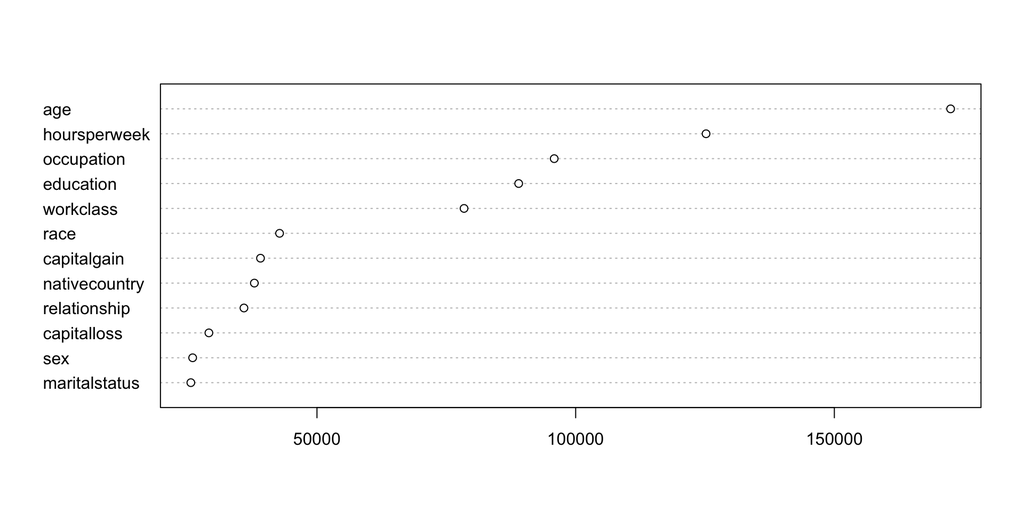

**Answer** :

1. **age**
2. maritalstatus
3. capitalgain
4. education

#### Problem 3.3

**Which one of the following variables is the most important in terms of mean reduction in impurity?**

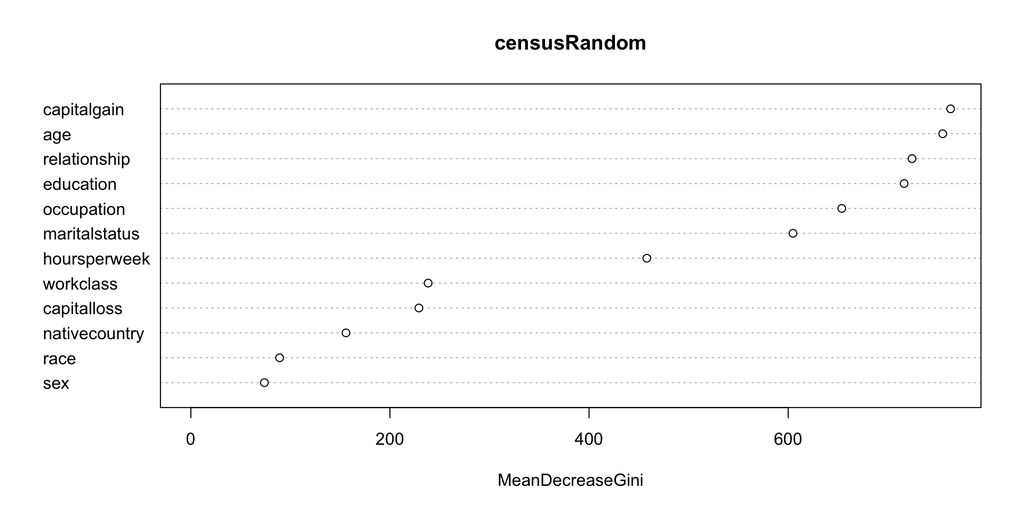

**Answer** :

1. workclass
2. **occupation**
3. sex
4. capitalloss

**Explanation** :  
If you generate the plot with the command varImpPlot(MODEL), you can see that occupation gives a larger reduction in impurity than the other variables.

Notice that the importance as measured by the average reduction in impurity is in general different from the importance as measured by the number of times the variable is selected for splitting. Although age and occupation are important variables in both metrics, the order of the variables is not the same in the two plots.

## **4. Selecting cp by Cross-Validation**

#### Problem 4.1

We now conclude our study of this data set by looking at how CART behaves with different choices of its parameters.

Also, remember to use the entire training set “train” when building this model. The train function might take some time to run.

**Which value of cp does the train function recommend?**

```
## CART
##
## 19187 samples
##    12 predictor
##     2 classes: ' <=50K', ' >50K'
##
## No pre-processing
## Resampling: Cross-Validated (10 fold)
## Summary of sample sizes: 17268, 17268, 17269, 17269, 17269, 17268, ...
## Resampling results across tuning parameters:
##
##   cp     Accuracy   Kappa
##   0.002  0.8510972  0.55404931
##   0.004  0.8482829  0.55537475
##   0.006  0.8452078  0.53914084
##   0.008  0.8442176  0.53817486
##   0.010  0.8433317  0.53305978
##   0.012  0.8433317  0.53305978
##   0.014  0.8433317  0.53305978
##   0.016  0.8413510  0.52349296
##   0.018  0.8400480  0.51528594
##   0.020  0.8381193  0.50351272
##   0.022  0.8381193  0.50351272
##   0.024  0.8381193  0.50351272
##   0.026  0.8381193  0.50351272
##   0.028  0.8381193  0.50351272
##   0.030  0.8381193  0.50351272
##   0.032  0.8381193  0.50351272
##   0.034  0.8352011  0.48749911
##   0.036  0.8326470  0.47340390
##   0.038  0.8267570  0.44688035
##   0.040  0.8248289  0.43893150
##   0.042  0.8248289  0.43893150
##   0.044  0.8248289  0.43893150
##   0.046  0.8248289  0.43893150
##   0.048  0.8248289  0.43893150
##   0.050  0.8231084  0.42467058
##   0.052  0.8174798  0.37478096
##   0.054  0.8138837  0.33679015
##   0.056  0.8118514  0.30751485
```

[output cut: 10 more lines]

```
##   0.078  0.7593684  0.00000000
##   0.080  0.7593684  0.00000000
##   0.082  0.7593684  0.00000000
##   0.084  0.7593684  0.00000000
##   0.086  0.7593684  0.00000000
##   0.088  0.7593684  0.00000000
##   0.090  0.7593684  0.00000000
##   0.092  0.7593684  0.00000000
##   0.094  0.7593684  0.00000000
##   0.096  0.7593684  0.00000000
##   0.098  0.7593684  0.00000000
##   0.100  0.7593684  0.00000000
##
## Accuracy was used to select the optimal model using the largest value.
## The final value used for the model was cp = 0.002.
```

**Answer** : 0.002

The final output should read  
Accuracy was used to select the optimal model using the largest value.  
The final value used for the model was cp = 0.002.

#### Poblem 4.2

Fit a CART model to the training data using this value of cp.  
**What is the prediction accuracy on the test set?**

$$Accuracy = \frac{TruePositive+TrueNegative}{Ntotal}$$

```
## [1] 0.8612306
```

**Answer** : 0.8612306

The accuracy is (9178+1838)/(9178+535+1240+1838) = 0.8612306.

#### Problem 4.3

Compared to the original accuracy using the default value of cp, this new CART model is an improvement, and so we should clearly favor this new model over the old one – or should we? Plot the CART tree for this model.

**How many splits are there?**

```
## [1] 0.8473927
```

```
## [1] 0.8612306
```

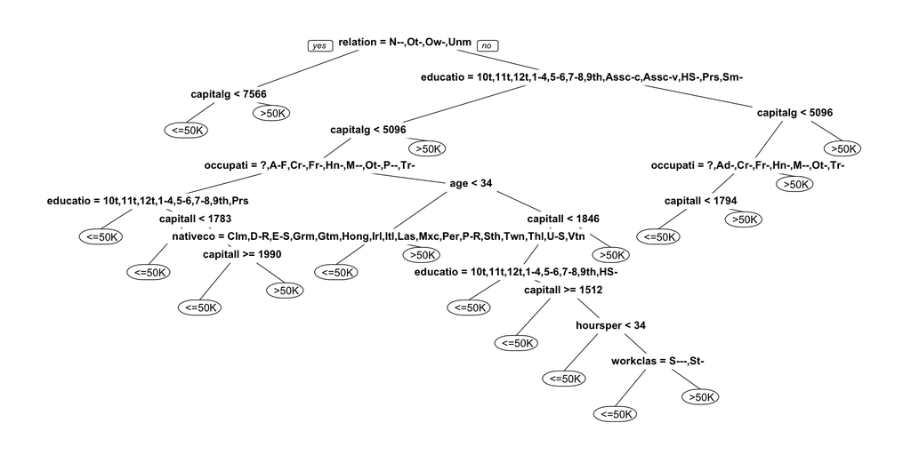

**Answer** : 18

**Explanation** :  
If you plot the tree with prp(model), where “model” is the name of your CART tree, you should see that there are 18 splits!

**This highlights one important tradeoff in building predictive models. By tuning cp, we improved our accuracy by over 1%, but our tree became significantly more complicated. In some applications, such an improvement in accuracy would be worth the loss in interpretability. In others, we may prefer a less accurate model that is simpler to understand and describe over a more accurate – but more complicated – model.**